# Fitting CoDa using the Logistic Gaussian distribution with Dirichlet covariance structure. An spatial simulation example

Joaquín Martínez-Minaya and Haavard Rue

2024-01-11

This document has been created with the purpose of showing how one can fit an LNDR model when dealing with compositional data.

```r
library(INLAcomp)
library(sp)
library(ggplot2)
library(dplyr)
library(viridis)
library(INLA)
library(raster)
library(inlabru)
library(parallel)
library(gridExtra)
```

# 1 Functions for plotting

```r
## --------------------------------------
#' Include a suffix to variable names
#'
#' Used with \code{\link[INLA]{inla.stack}} for building effect stacks.
#'
#' @param x a data.frame
#' @param suffix character string to be appended to variable names
#' @param makeNA logical. If \code{TRUE}, returns the suffixed data.frame filled
#'   with \code{NA}.
#' @export
suffix <- function(x, suffix, makeNA = FALSE) {
  z <- structure(x, names = paste(names(x), suffix, sep = '.'))
  if(makeNA) z[] <- NA
  z
}

### --- function to convert matrix to raster --- ####
rotate <- function(x)(apply(x,2,rev))

matrix_to_raster <- function(m, proj.grid.mat = proj.grid.mat)
{
  raster(rotate(t(m)),
         xmn = min(proj.grid.mat$lattice$loc[,1]),
         xmx = max(proj.grid.mat$lattice$loc[,1]),
         ymn = min(proj.grid.mat$lattice$loc[,2]),
         ymx = max(proj.grid.mat$lattice$loc[,2]))
}

# Legend
g_legend <- function(a.gplot) {
  tmp <- ggplot_gtable(ggplot_build(a.gplot))
  leg <- which(sapply(tmp$grobs, function(x) x$name) == "guide-box")
  legend <- tmp$grobs[[leg]]
  return(legend) }


###
raster_spatial_effect <- function(spatial, boundary,
                                  boundary1 = INLAcomp::polygon_IP,
                                  rast = TRUE,
                                  res = c(5000, 5000))
{

  if(rast == TRUE){
    res <- res(raster_predict)
  }
  proj <- inla.mesh.projector(mesh,
                              xlim = bbox(boundary)[1,],
                              ylim = bbox(boundary)[2,],
                              dims = c(round((bbox(boundary)[1,"max"] - bbox(boundary)[1,"min"])/res[1],0),
                                       round((bbox(boundary)[2,"max"]-bbox(boundary)[2,"min"])/res[2],0)))

  if(length(spatial) == mesh$n)
  {
    field.proj = inla.mesh.project(proj, spatial[1:mesh$n])

    field1 <- matrix_to_raster(field.proj, proj.grid.mat = proj)
    #field1 <- crop(field1, boundary)
    #field1 <- mask(field1, boundary)
    #plot(field1)
  }else{
    res <- matrix(spatial, byrow = FALSE, ncol = k-1)
    total <- apply(res, 2,
                   function(x){
                     res1 <- inla.mesh.project(proj, x)
                     field1 <- matrix_to_raster(res1, proj.grid.mat = proj)
                     #field1 <- crop(field1, boundary1)
                     #field1 <- mask(field1, boundary1)
                     #plot(field1)
                     #field1
                   })
    field1 <- raster::stack(total)
  }
  field1
}


#Plotting rasters
plot_raster <- function(rast, cat, names,
                        sc = FALSE,
                        col1 = "B",
                        ymin = 0, ymax = 1,
                        legkeywidth = 1,
                        poly)
{
  sp_eus2 <- fortify(poly)
  rast_gc1 <- as(rast[[cat]], "SpatialPixelsDataFrame")
  rast_gc1 <- as.data.frame(rast_gc1)
  colnames(rast_gc1) <- c("value", "lon", "lat")

  gc1_pred <- ggplot() +
    geom_tile(data = rast_gc1, aes(x = lon, y = lat, fill = value)) +
    # geom_polygon(data = poly, aes(x = long, y = lat, group = group),
    #              fill = NA, color = "gray20", size = 0.25) +
    coord_equal(ratio = 1) +
    ggtitle(names) +
    theme(line = element_blank(), # remove axis lines ..
          axis.text = element_blank(),                       # .. tickmarks..
          axis.title = element_blank(),
          panel.background = element_blank(),
          legend.position = "bottom",
          legend.key.height = unit(0.5, "cm"),
          legend.key.width = unit(legkeywidth, "cm"),
          legend.title = element_blank(),
          legend.text = element_text(size = 14),
          plot.title = element_text(size = 14, hjust = 0.5, vjust = -3)) +
    #scale_fill_viridis(option = col1, direction = -1, limits = c(ymin, ymax)) +
    scale_fill_gradientn(colours = rev(RColorBrewer::brewer.pal(11, "RdYlBu")),
                         limits = c(ymin, ymax))
  if(sc == TRUE)
  {

    gc1_pred <- gc1_pred +
      ggsn::scalebar(sp_eus2, location = "bottomright",
                     dist = 200, transform = FALSE,
                     st.size = 3, st.dist = 0.05, height=0.03,
                     dist_unit = "km")
    #ggsn::north(sp_eus2, location = "topright", scale = 0.2,
    #            symbol = 4)
    #ggsn::north2(sp_eus2, x = 0.65, y = 0.9, scale = 0.1, symbol = 1)
    #

  }
  gc1_pred

}




colsc <- function(...) {
  scale_fill_gradientn(
    colours = rev(RColorBrewer::brewer.pal(11, "RdYlBu")),
    limits = range(..., na.rm = TRUE)
  )
}
```

# 2 Simulating a dataset with replicate random effects

Defining some parameters and seeds for replicating.

```r
true_range <- 4
true_sigma <- 1
D <- 3
N <- 1000


set.seed(314)
inla.seed = sample.int(n=1E6, size=1)
```

## 2.1 Constructing a 2D model in a grid

We will now construct a 2D model, generate a sample of a random field, and attempt to recover the field from observations at a few locations. First, we build a high resolution mesh for the true field, using low level INLA functions.

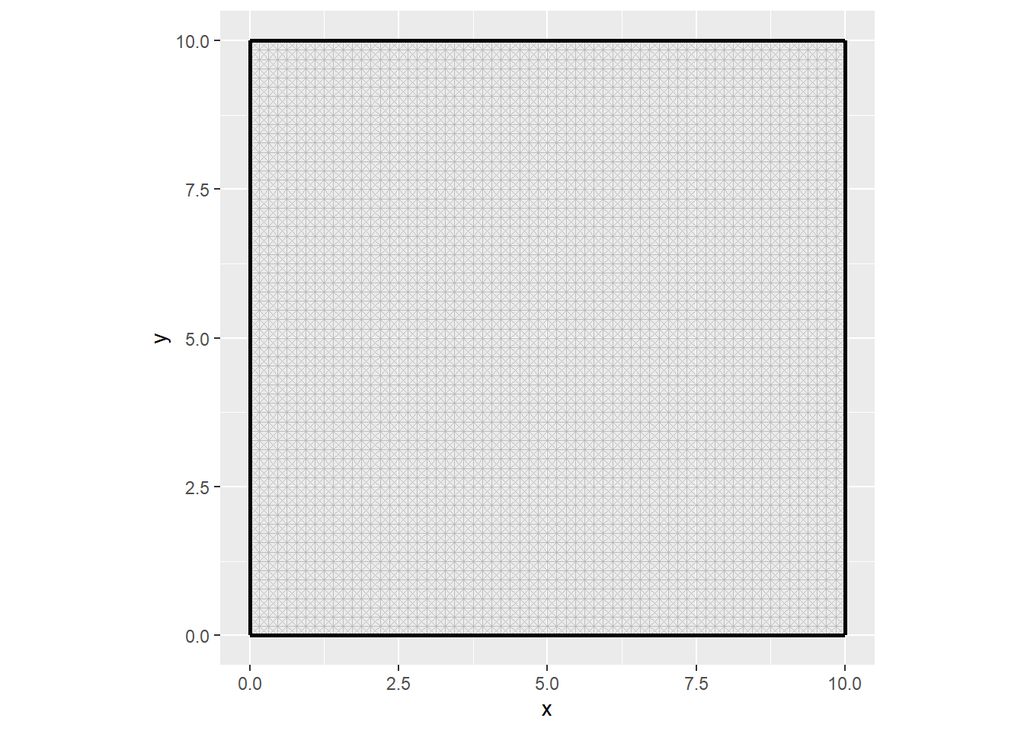

```r
bnd <- inlabru::spoly(data.frame(x = c(0, 10, 10, 0), y = c(0, 0, 10, 10)))
mesh_fine <- inla.mesh.2d(boundary = bnd, max.edge = 0.2)
ggplot() +
  gg(mesh_fine) +
  coord_equal()
```

```r
# Note: the priors here will not be used in estimation
matern_fine <-
  inla.spde2.pcmatern(mesh_fine,
                      prior.sigma = c(1, 0.01),
                      prior.range = c(1, 0.01)
  )

true_Q <- inla.spde.precision(matern_fine, theta = log(c(true_range, true_sigma)))
```

## 2.2 Samples from the fields

Generating a couple of samples from the model:

```r
true_field <- inla.qsample(D-1, true_Q, seed = inla.seed)
```

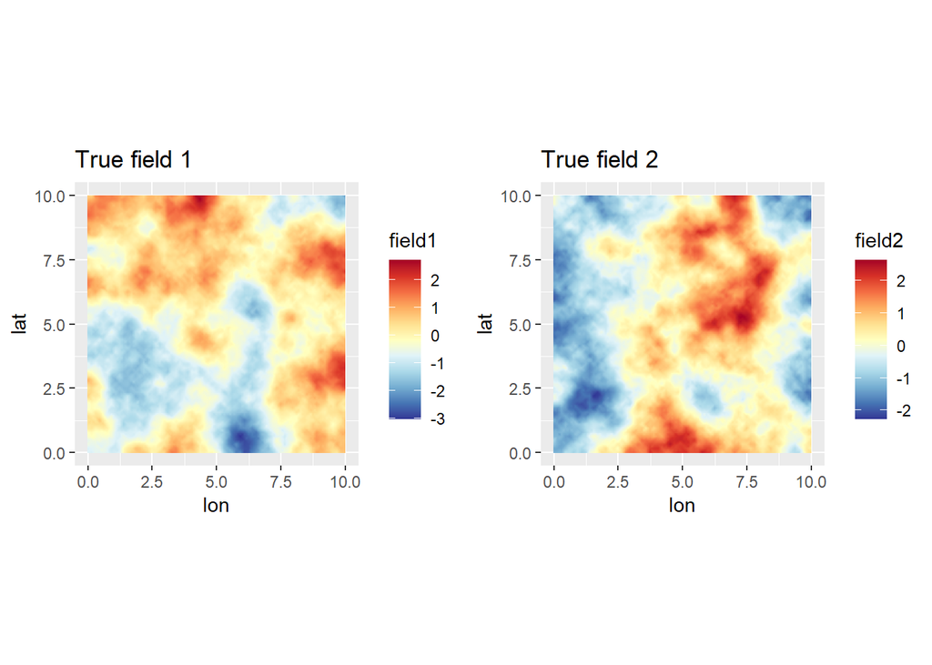

```r
truth <- expand.grid(
  lon = seq(0, 10, length = 500),
  lat = seq(0, 10, length = 500))
raster_predict <- rasterFromXYZ(truth)
raster_predict[!is.na(raster_predict)] <- 0


truth <- fm_evaluate(
  mesh_fine,
  loc = as.matrix(truth),
  field = true_field
) %>% cbind(truth, .)
names(truth) <- c("lon", "lat", paste0("field", 1:(D-1)))

coordinates(truth) <- c("lon", "lat")
truth <- as(truth, "SpatialPixelsDataFrame")

plot_truth <- lapply(1:(D-1), function(dd){
  csc1 <- colsc(truth[[dd]])
  ggplot() +
    gg(truth, mapping = aes_string("lon", "lat", fill = paste0("field", dd))) +
    coord_equal() +
    ggtitle(paste0("True field ", dd)) + csc1
})
truth_r <- stack(truth)
multiplot(plotlist = plot_truth,  cols = (D-1))
```

## 2.3 Observations from points. Adding covariates

Extract observations from some random locations:

```r
set.seed(51)
D <- k <- D
#betas <- matrix(c(2.2, -2.4), nrow = D-1, byrow = FALSE)
(betas <- matrix(c(2 + runif(1, -0.5, 0.5),
                    -2 + runif(1, -0.5, 0.5)), nrow = D-1, byrow = FALSE))
```

```
#>           [,1]
#> [1,]  2.275975
#> [2,] -2.299530
```

```r
#Covariance matrix of the response
sigma2 <- runif( D-1, 0.2, 0.6) %>% round(., 2)
cov_param <- 0.1

data <- data.frame(lon = runif(N, 0, 10),
                   lat = runif(N, 0, 10))

sigma_diag <- sqrt(sigma2 + cov_param)

hypers_lik <- data.frame(hypers = c(sigma2, cov_param),
                         name1 = c("sigma2.1", "sigma2.2",
                                   "gamma"))


# We create the correlation parameters based on the previous idea
# We are going to have ((D-1)^2 - (D-1))/2 rhos
rho <- diag(1/sigma_diag) %*% matrix(cov_param, D-1, D-1) %*% diag(1/sigma_diag)
diag(rho) <- 1
rho
```

```
#>           [,1]      [,2]
#> [1,] 1.0000000 0.1857594
#> [2,] 0.1857594 1.0000000
```

```r
#We define the covariate $\boldsymbol{x}$ and also, the corresponding betas, constructing the corresponding linear predictor.
xx <- runif(N)-0.5
data$xx <- xx


# - mean 0 to not affect intercept
X <- data.frame(xx) %>% as.matrix(.)


#Spatial effects. Two different random fields
spatial <- fm_evaluate(
  mesh_fine,
  loc = as.matrix(data),
  field = true_field
)

#Linear predictors
lin.pred <- X %*% t(betas) + spatial
```

## 2.4 alr-coordinates

We construct the $alr$-coordinates

```r
Sigma <- matrix(sigma_diag, ncol = 1) %*% matrix(sigma_diag, nrow = 1)
Sigma <- Sigma*rho

lin.pred %>%
  apply(., 1, function(z)
    MASS::mvrnorm( n  = 1,
                   mu = z,
                   Sigma = Sigma)) %>%
  t(.)-> alry
colnames(alry) <- paste0("alr.y", (1:(D-1)))
```

## 2.5 Data in the simplex

We move back to the Simplex using the $alr$-inverse, in particular, we use the function `alrInv` form the R-package `compositions`.

```r
y.simplex <- compositions::alrInv(alry)
y.simplex <- as.numeric(t(y.simplex)) %>% matrix(., ncol = D, byrow = TRUE)
colnames(y.simplex) <- paste0("y", 1:D)
data <- cbind(data, alry, y.simplex)
data %>% head(.)
```

|  | lon | lat | xx | alr.y1 | alr.y2 | y1 | y2 | y3 |
| --- | --- | --- | --- | --- | --- | --- | --- | --- |
| 1 | 2.164178 | 7.5629924 | -0.33326109 | 0.6539450 | 2.184931 | 0.16279430 | 0.75255424 | 0.08465147 |
| 2 | 8.344236 | 7.7793818 | -0.04749689 | 1.9900843 | 1.322445 | 0.60620677 | 0.31093452 | 0.08285871 |
| 3 | 7.513832 | 8.1528313 | -0.49554979 | -0.0792013 | 2.153185 | 0.08768465 | 0.81740353 | 0.09491181 |
| 4 | 4.060105 | 0.2253018 | 0.45511586 | 2.9632346 | 1.980221 | 0.70134426 | 0.26243020 | 0.03622553 |
| 5 | 9.710200 | 2.8148251 | 0.49812543 | 3.2641310 | -1.922874 | 0.95802063 | 0.00535411 | 0.03662526 |
| 6 | 1.123315 | 1.1945009 | 0.16154746 | -0.2999055 | -2.569754 | 0.40765427 | 0.04212202 | 0.55022371 |

## 2.6 Plotting the response

```r
bound <- fortify(bnd)
```

```r
data_plot <- data %>%
  dplyr::select(all_of(c("lon", "lat", paste0("y", 1:D)))) %>%
  tidyr::pivot_longer(all_of(paste0("y", 1:D)))


p1 <- ggplot() +
  geom_polygon(data = bound, aes(x = long,
                                 y = lat),
               colour = 'gray70', fill = 'gray90') +
  geom_point(data = data_plot,
             aes(x = lon,
                 y = lat,
                 #size = value,
                 color = value),
             alpha = 0.8, size = 3) +
  coord_fixed(ratio = 1) +
  facet_wrap(~ name, ncol = 4) +
  theme_bw() +
  theme(line = element_blank(),                          # remove axis lines ..
        axis.text = element_blank(),                       # .. tickmarks..
        axis.title = element_blank(),
        panel.background = element_blank(),
        legend.position = "bottom",
        legend.key.height = unit(0.5, "cm"),
        legend.key.width = unit(1.5, "cm"),
        legend.title = element_text(size = 17),
        legend.text = element_text(size = 15),
        strip.text = element_text(size = 15)) +
  #guides(fill = guide_legend(title.position="top", title.hjust = 0.5)) +
  xlab("") +
  ylab("") +
  scale_color_viridis(option="magma", direction = -1, limits = c(0, 1),
                      name = "")
getwd()
```

```
#> [1] "C:/Users/jomar/GITHUB/CODA/INLAcomp/simulations"
```

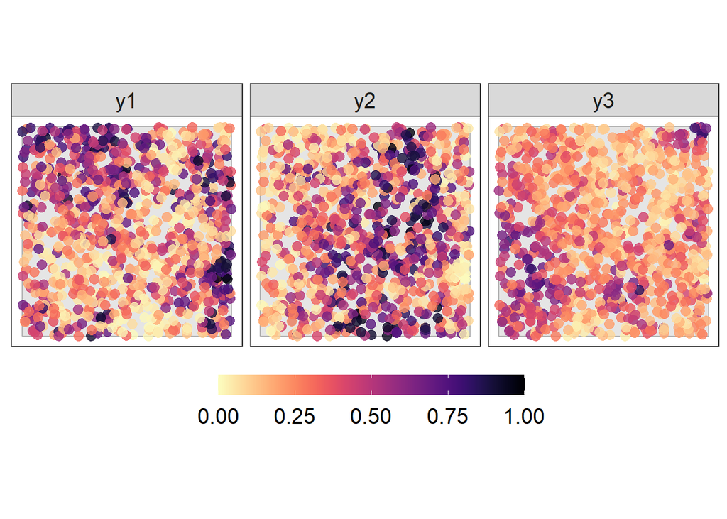

```r
#pdf("simulation_data.pdf", width = 10, height = 5)
print(p1)
```

```r
#dev.off()
```

## 2.7 Plotting the alr-coordiantes

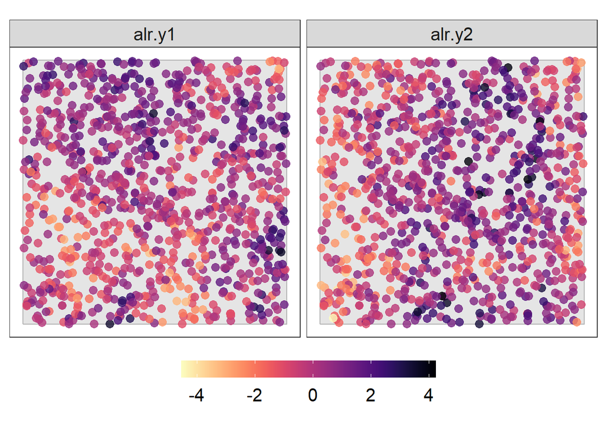

```r
 data_plot_alr <- data %>%
    dplyr::select(all_of(c("lon", "lat", paste0("alr.y", 1:(D-1))))) %>%
    tidyr::pivot_longer(all_of(paste0("alr.y", 1:(D-1))))


  #Plotting the map
  p2 <- ggplot() +
    geom_polygon(data = bound, aes(x = long,
                                   y = lat),
                 colour = 'gray70', fill = 'gray90') +
    geom_point(data = data_plot_alr,
               aes(x = lon,
                   y = lat,
                   #size = value,
                   color = value),
               alpha = 0.8, size = 3) +
    coord_fixed(ratio = 1) +
    facet_wrap(~ name) +
    theme_bw() +
    theme(line = element_blank(),                          # remove axis lines ..
          axis.text = element_blank(),                       # .. tickmarks..
          axis.title = element_blank(),
          panel.background = element_blank(),
          legend.position = "bottom",
          legend.key.height = unit(0.5, "cm"),
          legend.key.width = unit(1.5, "cm"),
          legend.title = element_text(size = 17),
          legend.text = element_text(size = 15),
          strip.text = element_text(size = 15)) +
    #guides(fill = guide_legend(title.position="top", title.hjust = 0.5)) +
    xlab("") +
    ylab("") +
    scale_color_viridis(option="magma", direction = -1,
                        name = "")
#pdf("simulation_data_alr.pdf", width = 9, height = 5)
  print(p2)
```

```r
#dev.off()
```

# 3 Preparing the data for fitting

## 3.1 Defining a new column with the values of all `alr` coordinates

```r
names_gc <- paste0("y", 1:(D-1))
data_ext <- data %>%
  tidyr::pivot_longer(., cols = all_of(paste0("alr.", names_gc)),
                      names_to  = "alr_gc",
                      values_to = "val_alr_gc") %>%
  .[order(ordered(.$alr_gc)),]
head(data_ext[, c("lon", "lat", "alr_gc", "val_alr_gc")])
```

| lon | lat | alr_gc | val_alr_gc |
| --- | --- | --- | --- |
| 2.164178 | 7.5629924 | alr.y1 | 0.6539450 |
| 8.344236 | 7.7793818 | alr.y1 | 1.9900843 |
| 7.513832 | 8.1528313 | alr.y1 | -0.0792013 |
| 4.060105 | 0.2253018 | alr.y1 | 2.9632346 |
| 9.710200 | 2.8148251 | alr.y1 | 3.2641310 |
| 1.123315 | 1.1945009 | alr.y1 | -0.2999055 |

## 3.2 Defining index for indiciating which alr-coordinate are we dealing with

```r
data_ext$alr_gc <- ordered(data_ext$alr_gc)
k.group <- data_ext$alr_gc %>% as.numeric() #For group
k.repl  <- data_ext$alr_gc %>% as.numeric() #For replication
head(data.frame(k.group, k.repl))
```

|  | k.group | k.repl |
| --- | --- | --- |
| 1 | 1 | 1 |
| 2 | 1 | 1 |
| 3 | 1 | 1 |
| 4 | 1 | 1 |
| 5 | 1 | 1 |
| 6 | 1 | 1 |

## 3.3 The mesh

We create the mesh as we usually do in **R-INLA** for spatial effects.

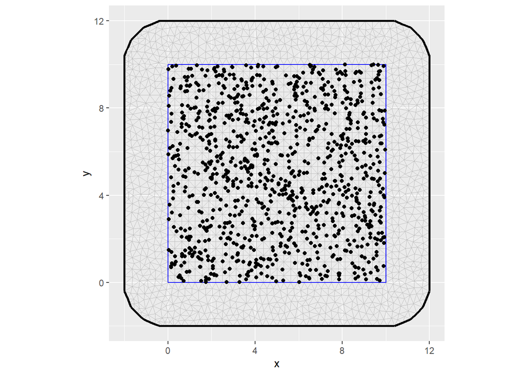

```r
mesh <- inla.mesh.2d(boundary = bnd,
                     max.edge = 0.5,
                     cutoff   = 0.1,
                     min.angle= 30,
                     offset   = c(0.2, 2))
ggplot() +
  gg(mesh) +
  coord_equal() +
  geom_point(data = data,
             aes(x = lon, y = lat))
```

## 3.4 Defining the spde

### 3.4.1 Defining spde with priors

We use PC-priors for defining the spde object.

```r
size <- 10
range0 <- size / 4  # ~ default
spde <- inla.spde2.pcmatern(mesh        = mesh,
                            prior.range = c(range0, 0.25), # P(range < range0) = 0.25
                            prior.sigma = c(1, 0.01)) # P(sigma > 1) = 0.01
```

### 3.4.2 Index for the spatial effects

We distinguish if we copy the spatial effect or we replicate it.

#### 3.4.2.1 Spatial index to be used in the model. We define it by alr-coordinate

This spatial index is useful when we replicate spatial effects, in other words, when we have one spatial effect per linear predictor whose realizations are different and hyperparameters are equal.

```r
iset <- inla.spde.make.index('i', n.spde = spde$n.spde,
                             n.repl  = k-1) #Replicating spatial effect
```

#### 3.4.2.2 This iset is for copy

This spatial index is useful when we copy spatial effects, in other words, when we have one spatial effect per linear predictor whose realizations are equal or proportionally equivalente, and hyperparameters are equal.

```r
iset2 <- inla.spde.make.index('i', n.spde = spde$n.spde)
iset_aux <- matrix(NA, ncol = k-1, nrow = k-1)
diag(iset_aux) <- rep(1, k-1)
iset2 <- kronecker(iset_aux, iset2$i)
colnames(iset2) <- paste0("iset.alr", 1:(k-1))
```

### 3.4.3 Defining the projection matrix

```r
A.est <- inla.spde.make.A(mesh  = mesh,
                          loc   = cbind(data_ext$lon, data_ext$lat),
                          repl  = k.repl)
A.est2 <- A.est
```

## 3.5 Defining the corresponding part to the shared random effect

### 3.5.1 Index for the random effect that is going to give the correlation

```r
id.z <- rep(1:(dim(data_ext)[1]/(k-1)), k-1)
```

### 3.5.2 Index for indicating the alr coordinate

```r
id.cat <- rep(1:(k-1), rep(N, k-1))
```

## 3.6 Defining the `inla.stack`

### 3.6.1 Response

```r
#Response
names_alr <- paste0("alr.", names_gc)


1:length(names_alr) %>%
  lapply(., function(i){
    data_ext %>%
      dplyr::filter(alr_gc == names_alr[i]) -> data_comp_i
    #Response
    y_alr <- matrix(ncol = names_alr %>% length(.), nrow = dim(data_comp_i)[1])
    y_alr[, i] <- data_comp_i$val_alr_gc
  }) -> y_alr

1:length(names_alr) %>%
  lapply(., function(i){
    y_aux <- data_ext %>%
      dplyr::select(val_alr_gc, alr_gc) %>%
      dplyr::filter(alr_gc == names_alr[i]) %>%
      dplyr::select(val_alr_gc) %>%
      as.matrix(.)
    aux_vec <- rep(NA, k-1)
    aux_vec[i] <- 1
    kronecker(aux_vec, y_aux)
  }) -> y_alr_list

y_alr <- do.call(cbind, y_alr_list)
y_alr[1:10,]
```

```
#>             [,1] [,2]
#>  [1,]  0.6539450   NA
#>  [2,]  1.9900843   NA
#>  [3,] -0.0792013   NA
#>  [4,]  2.9632346   NA
#>  [5,]  3.2641310   NA
#>  [6,] -0.2999055   NA
#>  [7,]  0.6946239   NA
#>  [8,]  0.4424407   NA
#>  [9,] -0.9911988   NA
#> [10,] -0.7300916   NA
```

### 3.6.2 Covariates

Covariates are going to be included in the model as random effects with big variance. So, we need the values of the covariates (the scaled one), and also, an index indicating to which alr-coordinate it belongs.

```r
variables <- c("intercept", data %>%
                 dplyr::select(xx) %>%
                 colnames(.))
id.names <- paste0("id.", variables)
id.variables <- rep(id.cat, length(variables)) %>%
  matrix(., ncol = length(variables), byrow = FALSE)
colnames(id.variables) <- id.names
```

### 3.6.3 Inla stack for estimation

```r
stk.est <- inla.stack(data    = list(resp = y_alr),
                      A       = list(A.est, 1, A.est2),
                      effects = list(c(iset),
                                     cbind(data_ext %>%
                                             dplyr::select(starts_with("xx")),
                                           id.z,
                                           id.variables,
                                           intercept = 1),
                                     data.frame(iset2)),
                      tag     = 'est')
```

# 4 Fitting the different models

## 4.1 Type I

Share the same parameters for fixed effects, and do not include spatial random e↵ects.

```r
list_prior <- rep(list(list(prior = "pc.prec", param = c(1, 0.01))), k-1)

formula.typeI <- resp ~ -1 +
  xx +
  f(id.z,
    model = "iid",
    hyper = list(prec = list(prior = "pc.prec",
                             param = c(1, 0.01))), constr = TRUE)

model.typeI <- inla(formula.typeI,
                   family         = rep("gaussian", k - 1),
                   data           = inla.stack.data(stk.est),
                   control.compute = list(config = TRUE,
                                          dic  = TRUE,
                                          waic = TRUE,
                                          cpo  = TRUE),
                   control.predictor = list(A = inla.stack.A(stk.est),
                                            compute = TRUE),
                   control.family = list_prior,
                   verbose = FALSE)
```

## 4.2 Type II

Have different parameters for fixed effects, and do not include spatial random e↵ects.

```r
formula.typeII <- resp ~ -1 +
  f(id.xx, xx, #BIO1
    model   = "iid",
    initial = log(1/10000),
    fixed   = TRUE) +
  f(id.z,
    model = "iid",
    hyper = list(prec = list(prior = "pc.prec",
                             param = c(1, 0.01))), constr = TRUE)

model.typeII <- inla(formula.typeII,
                   family         = rep("gaussian", k - 1),
                   data           = inla.stack.data(stk.est),
                   control.compute = list(config = TRUE,
                                          dic  = TRUE,
                                          waic = TRUE,
                                          cpo  = TRUE),
                   control.predictor = list(A = inla.stack.A(stk.est),
                                            compute = TRUE),
                   control.family = list_prior,
                   verbose = FALSE)
```

## 4.3 Type III

Share the same parameters for fixed effects, and share the same spatial effect.

```r
formula.typeIII <- resp ~ -1 +
  xx +
  f(iset.alr1, model = spde) +
  f(iset.alr2, copy = "iset.alr1",
    fixed = TRUE) +
  f(id.z,
    model = "iid",
    hyper = list(prec = list(prior = "pc.prec",
                             param = c(1, 0.01))), constr = TRUE)

model.typeIII <- inla(formula.typeIII,
                   family         = rep("gaussian", k - 1),
                   data           = inla.stack.data(stk.est),
                   control.compute = list(config = TRUE,
                                          dic  = TRUE,
                                          waic = TRUE,
                                          cpo  = TRUE),
                   control.predictor = list(A = inla.stack.A(stk.est),
                                            compute = TRUE),
                   control.family = list_prior,
                   verbose = FALSE)
```

## 4.4 Type IV

Have different parameters for fixed effects, and share the same spatial effect.

```r
list_prior <- rep(list(list(prior = "pc.prec", param = c(1, 0.01))), k-1)

formula.typeIV <- resp ~ -1 +
  f(id.xx, xx,
    model   = "iid",
    initial = log(1/10000),
    fixed   = TRUE) +
  f(iset.alr1, model = spde) +
  f(iset.alr2, copy = "iset.alr1",
    fixed = TRUE) +
  f(id.z,
    model = "iid",
    hyper = list(prec = list(prior = "pc.prec",
                             param = c(1, 0.01))),
    constr = TRUE)

model.typeIV <- inla(formula.typeIV,
                   family         = rep("gaussian", k - 1),
                   data           = inla.stack.data(stk.est),
                   control.compute = list(config = TRUE,
                                          dic  = TRUE,
                                          waic = TRUE,
                                          cpo  = TRUE),
                   control.predictor = list(A = inla.stack.A(stk.est),
                                            compute = TRUE),
                   control.family = list_prior,
                   verbose = FALSE)
```

## 4.5 Type V

Share the same parameters for fixed effects, and the spatial effects between linear predictors are proportional.

```r
formula.typeV <- resp ~ -1 +
  xx +
  f(iset.alr1, model = spde) +
  f(iset.alr2, copy = "iset.alr1",
    fixed = FALSE) +
  f(id.z,
    model = "iid",
    hyper = list(prec = list(prior = "pc.prec",
                             param = c(1, 0.01))), constr = TRUE)

model.typeV <- inla(formula.typeV,
                   family         = rep("gaussian", k - 1),
                   data           = inla.stack.data(stk.est),
                   control.compute = list(config = TRUE,
                                          dic  = TRUE,
                                          waic = TRUE,
                                          cpo  = TRUE),
                   control.predictor = list(A = inla.stack.A(stk.est),
                                            compute = TRUE),
                   control.family = list_prior,
                   verbose = FALSE)
```

## 4.6 Type VI

Have different parameters for fixed effects, and the spatial effects between linear predictors are proportional

```r
list_prior <- rep(list(list(prior = "pc.prec", param = c(1, 0.01))), k-1)

formula.typeVI <- resp ~ -1 +
  f(id.xx, xx, #xx
    model   = "iid",
    initial = log(1/10000),
    fixed   = TRUE) +
  f(iset.alr1, model = spde) +
  f(iset.alr2, copy = "iset.alr1",
    hyper = list(beta = list(fixed = FALSE, params = c(0, 1)))) +
  f(id.z,
    model = "iid",
    hyper = list(prec = list(prior = "pc.prec",
                             param = c(1, 0.01))),
    constr = TRUE)



model.typeVI <- inla(formula.typeVI,
                   family         = rep("gaussian", k - 1),
                   data           = inla.stack.data(stk.est),
                   control.compute = list(config = TRUE,
                                          dic  = TRUE,
                                          waic = TRUE,
                                          cpo  = TRUE),
                   control.predictor = list(A = inla.stack.A(stk.est),
                                            compute = TRUE),
                   control.family = list_prior,
                   verbose = FALSE)

#model.typeVI <- inla.rerun(model.typeVI)
```

## 4.7 Type VII

Share the same parameters for fixed effects, and different realisations of the spatial effect for each linear predictor

```r
formula.typeVII <- resp ~ -1 +
  xx +
  f(i,
    model = spde,
    replicate = i.repl) +
  f(id.z,
    model = "iid",
    hyper = list(prec = list(prior = "pc.prec",
                             param = c(1, 0.01))), constr = TRUE)

model.typeVII <- inla(formula.typeVII,
                   family         = rep("gaussian", k - 1),
                   data           = inla.stack.data(stk.est),
                   control.compute = list(config = TRUE,
                                          dic  = TRUE,
                                          waic = TRUE,
                                          cpo  = TRUE),
                   control.predictor = list(A = inla.stack.A(stk.est),
                                            compute = TRUE),
                   control.family = list_prior,
                   inla.mode = "experimental" ,
                   verbose = FALSE)
```

## 4.8 Type VIII

Have different parameters for fixed effects, and different realisations of the spatial effect for each linear predictor

```r
list_prior <- rep(list(list(prior = "pc.prec", param = c(1, 0.01))), k-1)

formula.typeVIII <- resp ~ -1 +
  f(id.xx, xx, #xx
    model   = "iid",
    initial = log(1/10000),
    fixed   = TRUE) +
  f(i,
    model = spde,
    replicate = i.repl) +
  f(id.z,
    model = "iid",
    hyper = list(prec = list(prior = "pc.prec",
                             param = c(1, 0.01))), constr = TRUE)

model.typeVIII <- inla(formula.typeVIII,
                   family         = rep("gaussian", k - 1),
                   data           = inla.stack.data(stk.est),
                   control.compute = list(config = TRUE,
                                          dic  = TRUE,
                                          waic = TRUE,
                                          cpo  = TRUE),
                   control.predictor = list(A = inla.stack.A(stk.est),
                                            compute = TRUE),
                   control.family = list_prior,
                   verbose = FALSE)
```

# 5 Comparing using DIC, WAIC and LCPO

In this tutorial, for the moment, we compute the DIC, WAIC and LCPO for all the models.

DIC and WAIC: We obtain the joint posterior distribution of the model using the `inla.posterior.sample` function. We use the functions `dic.mult` and `waic.mult` for computing the new DIC and WAIC.

CPO: We define friends in our dataset. We use the function `inla.group.cv` with the argument `num.level.sets = -1` for computing the CPO.

```r
model_list <- list(model.typeI,
               model.typeII,
               model.typeIII,
               model.typeIV,
               model.typeV,
               model.typeVI,
               model.typeVII,
               model.typeVIII)

names(model_list) <- paste0("type", c("I", "II", "III", "IV", "V", "VI", "VII", "VIII"))

## Computing measures of this model
measures <- lapply(model_list, function(mod1){
  xx <- inla.posterior.sample(1000, mod1, seed = inla.seed)
  inf <- parallel::mclapply(xx, INLAcomp::extract_lp_sigma)

  #DIC
  dic.mod1 <- INLAcomp::dic.mult(inf, y = data[, c(paste0("alr.y", 1:(k-1)))])

  #WAIc
  waic.mod1 <- INLAcomp::waic.mult(inf, y = data[, c(paste0("alr.y", 1:(k-1)))])

  #lIST FOR cpo
  friends_list <- 1:(N*(D-1)) %>%
  lapply(., function(x){
    c(seq(x, N*(D-1), by = N)[-1],
      rev(seq(x, 1, by = -N))) -> res
    res[order(res)]
  })


  a4 <- INLA::inla.group.cv(result = mod1,
                          num.level.sets = -1,
                          strategy = "posterior",
                          friends = friends_list,
                          verbose = FALSE)

  LCPO <- a4$cv %>% log(.) %>% mean(.) %>% -.

data.frame(DIC = dic.mod1, WAIC = waic.mod1, LCPO = LCPO)

})







measures <-  as.data.frame(do.call(rbind, measures))

xtable::xtable(measures[, c("DIC.dic", "WAIC.waic", "LCPO")], digits = 3)
```

|  | DIC.dic | WAIC.waic | LCPO |
| --- | --- | --- | --- |
| typeI | 6822.373 | 6822.132 | 1.704199 |
| typeII | 6265.526 | 6265.444 | 1.570813 |
| typeIII | 6221.405 | 6205.634 | 1.545612 |
| typeIV | 5585.606 | 5569.301 | 1.386441 |
| typeV | 6068.076 | 6072.944 | 1.516804 |
| typeVI | 5397.224 | 5405.861 | 1.302488 |
| typeVII | 5772.775 | 5782.855 | 1.445805 |
| typeVIII | 4694.686 | 4711.903 | 1.175747 |

# 6 Checking posterior distributions of the best model

## 6.1 Recovering spatial random fields

We represent the median and credible intervals 95% for the spatial random fields.

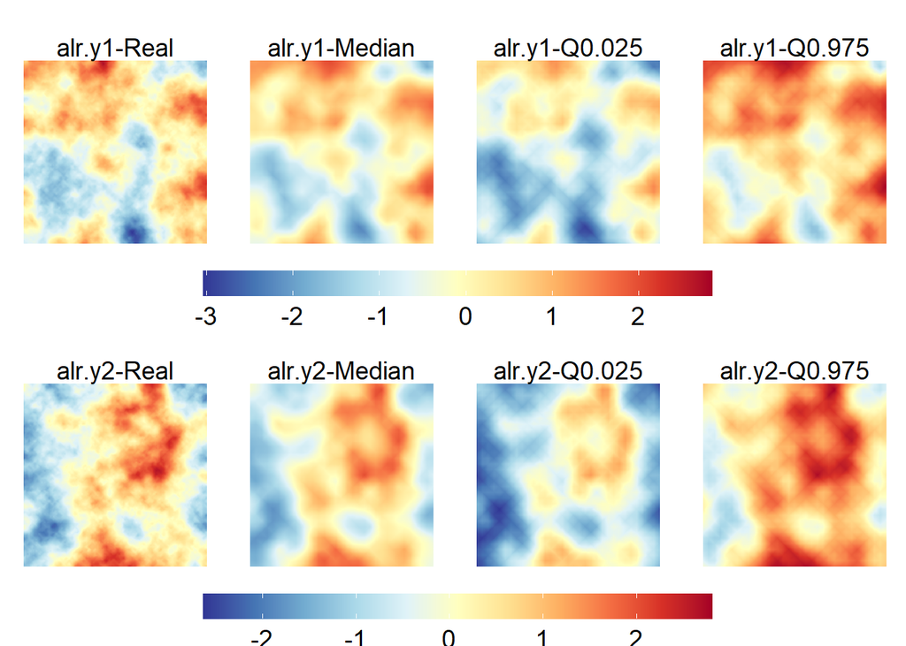

```r
model <- model.typeVIII
spatial_median <- raster_spatial_effect(spatial = model$summary.random[['i']][['0.5quant']],
                                      boundary = raster_predict,
                                      boundary1 = bnd)

spatial_q.025 <- raster_spatial_effect(spatial = model$summary.random[['i']][["0.025quant"]],
                                         boundary = raster_predict,
                                         boundary1 = bnd)

spatial_q.975 <- raster_spatial_effect(spatial = model$summary.random[['i']][["0.975quant"]],
                                         boundary = raster_predict,
                                         boundary1 = bnd)

range.sp1 <- range(c(values(spatial_median[[1]]), values(truth_r[[1]]),
                   values(spatial_q.975[[1]]), values(spatial_q.025[[1]])))
range.sp2 <- range(c(values(spatial_median[[2]]), values(truth_r[[2]]),
                   values(spatial_q.975[[2]]), values(spatial_q.025[[2]])))
#Plotting
p1.alr1.Real <- plot_raster(rast = truth_r,
                            ymin = range.sp1[1], ymax = range.sp1[2],
                            poly = bnd,
                            cat = 1,
                            names = "alr.y1-Real",
                            legkeywidth = 2)
p1.alr1.median <- plot_raster(rast = spatial_median,
                            ymin = range.sp1[1], ymax = range.sp1[2],
                            poly = bnd,
                            cat = 1,
                            names = "alr.y1-Median",
                            legkeywidth = 2)
p1.alr1.025 <- plot_raster(rast = spatial_q.025,
                            ymin = range.sp1[1], ymax = range.sp1[2],
                            poly = bnd,
                            cat = 1,
                            names = "alr.y1-Q0.025",
                            legkeywidth = 2)
p1.alr1.975 <- plot_raster(rast = spatial_q.975,
                            ymin = range.sp1[1], ymax = range.sp1[2],
                            poly = bnd,
                            cat = 1,
                            names = "alr.y1-Q0.975",
                            legkeywidth = 2)
## alr2
p1.alr2.Real <- plot_raster(rast = truth_r,
                            ymin = range.sp2[1], ymax = range.sp2[2],
                            poly = bnd,
                            cat = 2,
                            names = "alr.y2-Real",
                            legkeywidth = 2)
p1.alr2.median <- plot_raster(rast = spatial_median,
                            ymin = range.sp2[1], ymax = range.sp2[2],
                            poly = bnd,
                            cat = 2,
                            names = "alr.y2-Median",
                            legkeywidth = 2)
p1.alr2.025 <- plot_raster(rast = spatial_q.025[[2]],
                           ymin = range.sp2[1], ymax = range.sp2[2],
                           poly = bnd,
                           cat = 1,
                           names = "alr.y2-Q0.025",
                           legkeywidth = 2)
p1.alr2.975 <- plot_raster(rast = spatial_q.975[[2]],
                            ymin = range.sp2[1], ymax = range.sp2[2],
                            poly = bnd,
                            cat = 1,
                            names = "alr.y2-Q0.975",
                            legkeywidth = 2)
mylegend_alr1 <- g_legend(p1.alr1.Real)
mylegend_alr2 <- g_legend(p1.alr2.Real)


gridExtra::grid.arrange(gridExtra::arrangeGrob(p1.alr1.Real + theme(legend.position = "none"),
                                    p1.alr1.median + theme(legend.position = "none"),
                                    p1.alr1.025 + theme(legend.position = "none"),
                                    p1.alr1.975 + theme(legend.position = "none"),
                                    nrow = 1),
                        gridExtra::arrangeGrob(mylegend_alr1,
                                    nrow = 1, widths = c(4)),
                        gridExtra::arrangeGrob(p1.alr2.Real + theme(legend.position = "none"),
                                    p1.alr2.median + theme(legend.position = "none"),
                                    p1.alr2.025 + theme(legend.position = "none"),
                                    p1.alr2.975 + theme(legend.position = "none"),
                                    nrow = 1),
                        gridExtra::arrangeGrob(mylegend_alr2, nrow = 1, widths = c(4)),
                        nrow = 4, ncol = 1, heights = c(6, 1, 6, 1))
```

```r
#png(paste0("spatial","_", N, ".png"), width = 1400, height = 1050, res = 150)
```

## 6.2 Recovering corresponding to the fixed effects

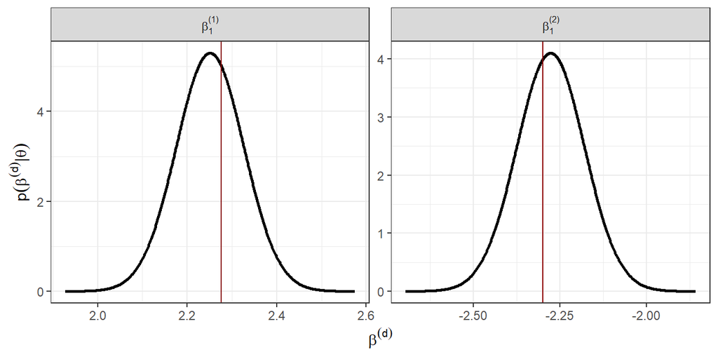

```r
lapply(1:(D-1), function(xx){
  data.frame(inla.smarginal(model$marginals.random$id.xx[[xx]]),
             alr = paste0("(", xx, ")"),
             var = "beta1")
}) %>% do.call(rbind.data.frame, .) -> data_fixed2
#data_fixed <- rbind(data_fixed, data_fixed2)
data_fixed <- data_fixed2
data_fixed$alrvar = data_fixed$alr

fixed.real <- data.frame(real = c(as.numeric((betas))),
                         alrvar = c(                          paste0("(", 1:(D-1), ")")))



p.fixed <- ggplot() +
  geom_line(data = data_fixed, aes(x = x, y = y), size = 0.9) +
  geom_vline(data = fixed.real, aes(xintercept = real), col = "red4") +
  theme_bw() +
  theme(legend.position = "bottom") +
  facet_wrap(~ alrvar, nrow = 1, scales = "free",
               labeller = label_bquote(beta [1] ^ .(alrvar))) +
  xlab(expression(beta^(d))) +
  ylab(expression(p(beta^(d) *'|'* theta))) +
  theme(legend.title = element_blank())
#pdf("posterior_fixed.pdf", width = 6, height = 5)
print(p.fixed)
```

```r
#dev.off()
```

## 6.3 Recovering hyperparameters

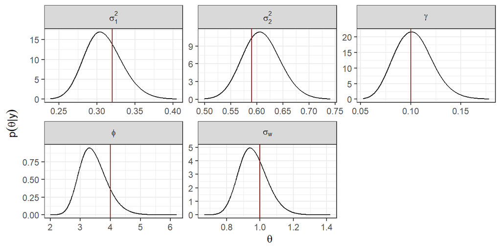

```r
prec <- model$marginals.hyperpar[1:(D-1)] %>%
  c(., list(model$marginals.hyperpar$`Precision for id.z`))

hyper <- lapply(1:length(prec),
                function(x){
                  inla.smarginal(inla.tmarginal(prec[[x]], fun = function(y)(1/y))) %>%
                    data.frame(.)
                })
names(hyper) <- c(paste0("sigma2.", 1:(D-1)), "gamma")

hyper <- c(hyper,
           sigma.sp = list(inla.smarginal(model$marginals.hyperpar[["Stdev for i"]])),
           phi = list(inla.smarginal(model$marginals.hyperpar[["Range for i"]])))
hyper.df <- lapply(1:length(hyper),
                   function(x){
                     cbind(data.frame(hyper[[x]]), name1 = names(hyper)[x])
                   })  %>%
  do.call(rbind.data.frame, .)

hyper.df$name1 <- ordered(hyper.df$name1,
                          levels = c(paste0("sigma2.", 1:(D-1)),
                                     "gamma", "phi", "sigma.sp"))
#hyper.df$name1 <- as.character(hyper.df$name1)


hyper.df$name1 <- ordered(hyper.df$name1,
                          levels = c("sigma2.1", "sigma2.2",
                                     "gamma", "phi", "sigma.sp"),
                          labels = c("sigma[1]^2", "sigma[2]^2", "gamma", "phi", "sigma[w]"))


hyper.real <- data.frame(real = c(sigma2, cov_param, true_range, true_sigma),
                         name1 = c(paste0("sigma2.", 1:(D-1)),
                                   "gamma", "phi", "sigma.sp"))

hyper.real$name1 <- as.factor(hyper.real$name1)
hyper.real$name1 <- ordered(hyper.real$name1,
                          levels = c("sigma2.1", "sigma2.2",
                                     "gamma", "phi", "sigma.sp"),
                          labels = c("sigma[1]^2", "sigma[2]^2", "gamma", "phi", "sigma[w]"))



p.hyper <- ggplot(hyper.df) +
  geom_line(aes(x = x, y = y)) +
  geom_vline(data = hyper.real, aes(xintercept = real), col = "red4") +
  facet_wrap(~ name1, scales = "free",
             labeller = label_parsed) +
  theme_bw() +
  xlab(expression(theta)) +
  ylab(expression(p(theta*'|'*y)))

#pdf("simulation_data_hyperpar.pdf", width = 9, height = 5)
print(p.hyper)
```

```r
#dev.off()
```